# Problem Set 02 Solutions

```r
library(dplyr)
library(ggplot2)
library(readr)
```

```r
nc <- read_csv("https://docs.google.com/spreadsheets/d/e/2PACX-1vTm2WZwNBoQdZhMgot7urbtu8eG7tzAq-60ZJsQ_nupykCAcW0OXebVpHksPWyR4x8xJTVQ8KAulAFS/pub?gid=202410847&single=true&output=csv")
```

```r
glimpse(nc)
```

[output not shown]

## Exercise 1

What type of variable is R considering the variable `habit` to be? What variable type is `visits`? (answer with text)

**Answer: habit is listed as (character), and visits is an integer**

```r
ggplot(data = nc, aes(x = weeks, y = weight)) +
  geom_point() +
  labs(x = "Length of pregnancy (in weeks)", y = "Birth weight of baby (lbs)",
       title = "Relationship between pregnancy duration and newborn weight")
```

[output not shown]

## Exercise 2

1. Is there a positive or negative relationship between these variables? (text only to answer)

**Answer: positive**

## Exercise 3

Make a graph showing `weeks` again on the x axis and the variabel `gained` on the y axis (the amount of weight a mother gained during pregnancy). Include axis labels with measurement units, and a title. (code only to answer)

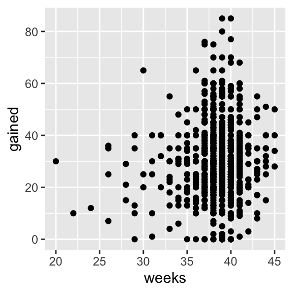

```r
ggplot(data = nc, aes(x = weeks, y = gained))+
  geom_point()
```

## Exercise 4

Study the code below, and the resulting graphical output.

**A.** What did adding the argument `color = premie` accomplish?

**Answer: the color of the points corresponds to whether a birth was a premie or a full term birth**

**B.** How many **variables** are now displayed on this plot?

**Answer: 3 variables are shown**

**C.** What appears to (roughly) be the pregnancy length cutoff for classifying a newborn as a “premie”" versus a “full term”.

**Answer: anywhere between 36 and 38 seems reasonable**

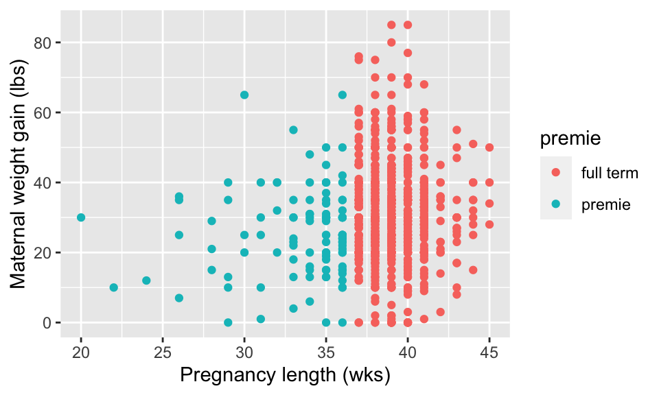

```r
ggplot(data = nc, aes(x = weeks, y = gained, color = premie))+
  geom_point() +
  labs(x = "Pregnancy length (wks)", y = "Maternal weight gain (lbs)")
```